# Data Mining Course Project

wangxhere

13 Jun, 2016

## Summary

One thing that people regularly do is quantify how much of a particular activity they do, but they rarely quantify how well they do it. The goal of this project is to predict the manner in which they did the exercise, which is a dumbell exercise of 6 participants. Sensing data are collected from accelerometers on the belt, forearm, arm, and dumbell.

## Acquire Data and Load Dependencies

Thanks to the provider of the data, which is available at http://groupware.les.inf.puc-rio.br/har.

```r
download.file("https://d396qusza40orc.cloudfront.net/predmachlearn/pml-training.csv", "training.csv")
download.file("https://d396qusza40orc.cloudfront.net/predmachlearn/pml-testing.csv", "testing.csv")
training <- read.csv("training.csv")
testing <- read.csv("testing.csv")
```

We here use the following libaries, and at the same time, setting random seeds for reproducibility.

```r
library(dplyr)
library(caret)
library(ggplot2)

set.seed(12315)
```

## Exploring Dataset

- Check NZV Columns

```r
nzv <- nearZeroVar(training, saveMetrics = TRUE)
rownames(nzv[nzv$zeroVar == TRUE,])
```

```
## character(0)
```

```r
rownames(nzv[nzv$nzv == TRUE,])
```

```
##  [1] "new_window"              "kurtosis_roll_belt"
##  [3] "kurtosis_picth_belt"     "kurtosis_yaw_belt"
##  [5] "skewness_roll_belt"      "skewness_roll_belt.1"
##  [7] "skewness_yaw_belt"       "max_yaw_belt"
##  [9] "min_yaw_belt"            "amplitude_yaw_belt"
## [11] "avg_roll_arm"            "stddev_roll_arm"
## [13] "var_roll_arm"            "avg_pitch_arm"
## [15] "stddev_pitch_arm"        "var_pitch_arm"
## [17] "avg_yaw_arm"             "stddev_yaw_arm"
## [19] "var_yaw_arm"             "kurtosis_roll_arm"
## [21] "kurtosis_picth_arm"      "kurtosis_yaw_arm"
## [23] "skewness_roll_arm"       "skewness_pitch_arm"
## [25] "skewness_yaw_arm"        "max_roll_arm"
## [27] "min_roll_arm"            "min_pitch_arm"
## [29] "amplitude_roll_arm"      "amplitude_pitch_arm"
## [31] "kurtosis_roll_dumbbell"  "kurtosis_picth_dumbbell"
## [33] "kurtosis_yaw_dumbbell"   "skewness_roll_dumbbell"
## [35] "skewness_pitch_dumbbell" "skewness_yaw_dumbbell"
## [37] "max_yaw_dumbbell"        "min_yaw_dumbbell"
## [39] "amplitude_yaw_dumbbell"  "kurtosis_roll_forearm"
## [41] "kurtosis_picth_forearm"  "kurtosis_yaw_forearm"
## [43] "skewness_roll_forearm"   "skewness_pitch_forearm"
## [45] "skewness_yaw_forearm"    "max_roll_forearm"
## [47] "max_yaw_forearm"         "min_roll_forearm"
## [49] "min_yaw_forearm"         "amplitude_roll_forearm"
## [51] "amplitude_yaw_forearm"   "avg_roll_forearm"
## [53] "stddev_roll_forearm"     "var_roll_forearm"
## [55] "avg_pitch_forearm"       "stddev_pitch_forearm"
## [57] "var_pitch_forearm"       "avg_yaw_forearm"
## [59] "stddev_yaw_forearm"      "var_yaw_forearm"
```

As those nzv variables are providing no significant contribution to the machine learning procedure, we filter them out before preprocessing phase.

```r
training.sel <- training %>%
  select(classe,
         user_name,
         roll_belt, pitch_belt, yaw_belt, total_accel_belt,
         gyros_belt_x, gyros_belt_y, gyros_belt_z,
         accel_belt_x, accel_belt_y, accel_belt_z,
         magnet_belt_x, magnet_belt_y, magnet_belt_z,
         roll_arm, pitch_arm, yaw_arm, total_accel_arm,
         gyros_arm_x, gyros_arm_y, gyros_arm_z,
         accel_arm_x, accel_arm_y, accel_arm_z,
         magnet_arm_x, magnet_arm_y, magnet_arm_z,
         roll_dumbbell, pitch_dumbbell, yaw_dumbbell
  )

testing.sel <- testing %>%
  select(user_name,
         roll_belt, pitch_belt, yaw_belt, total_accel_belt,
         gyros_belt_x, gyros_belt_y, gyros_belt_z,
         accel_belt_x, accel_belt_y, accel_belt_z,
         magnet_belt_x, magnet_belt_y, magnet_belt_z,
         roll_arm, pitch_arm, yaw_arm, total_accel_arm,
         gyros_arm_x, gyros_arm_y, gyros_arm_z,
         accel_arm_x, accel_arm_y, accel_arm_z,
         magnet_arm_x, magnet_arm_y, magnet_arm_z,
         roll_dumbbell, pitch_dumbbell, yaw_dumbbell
  )
```

In order for the machine learning algorithm to perform easier, we assign numerical values to levels of the “classe” Factor.

```r
testing.sel$classe <- factor(c(1, 2, 3, 4, 5))
levels(training.sel$classe) <- c(1, 2, 3, 4, 5)
```

In order to help the training sample to cover as many users as possible, we sample from training.sel according to both “classe” and “user_name”.

```r
inTrain <- createDataPartition(interaction(training.sel$classe, training.sel$user_name), p=0.7, list=FALSE)

train.set <- training.sel[inTrain,]
validation.set <- training.sel[-inTrain,]
```

In order to reduce the time for training the model, we use PCA preprocessing to reduce the independent dimension. Also, in order to help the training cover as much part of variance as possible, we center and scale those data, which is a mixture of angular and linear measurements.

```r
preProc <- preProcess(train.set, method = c("center", "scale", "pca"), thresh = 0.99, na.remove = TRUE)

train.pc <- predict(preProc, train.set)
validation.pc <- predict(preProc, validation.set)
```

As for cross validation, we are replacing the default “boot” method of training control to “repeatedcv”, for a more accurate control of validation set slicing.

```r
fitControl <- trainControl(method = "repeatedcv", number = 10, repeats = 10)
```

```r
rfModel <- train(classe ~ .-(classe+user_name), data = train.pc, method = "rf", ntree = 550, trControl = fitControl)
```

After this, we use validation set that is selected previously, to generate a confusion matrix, in order to judge the accuracy of the model trained.

```r
validation.pred.pc <- predict(rfModel, validation.pc)
confusionMatrix(validation.set$classe, validation.pred.pc)
```

```
## Confusion Matrix and Statistics
##
##           Reference
## Prediction    1    2    3    4    5
##          1 1599   31   21   18    3
##          2   59 1021   32   19    5
##          3   13   22  972   13    3
##          4    7   19   58  871    6
##          5    3   13   13    8 1042
##
## Overall Statistics
##
##                Accuracy : 0.9377
##                  95% CI : (0.9312, 0.9437)
##     No Information Rate : 0.2863
##     P-Value [Acc > NIR] : < 2.2e-16
##
##                   Kappa : 0.9211
##  Mcnemar's Test P-Value : 2.145e-08
##
## Statistics by Class:
##
##                      Class: 1 Class: 2 Class: 3 Class: 4 Class: 5
## Sensitivity            0.9512   0.9231   0.8869   0.9376   0.9839
## Specificity            0.9826   0.9759   0.9893   0.9818   0.9923
## Pos Pred Value         0.9563   0.8988   0.9501   0.9063   0.9657
## Neg Pred Value         0.9805   0.9820   0.9744   0.9882   0.9965
## Prevalence             0.2863   0.1884   0.1867   0.1582   0.1804
## Detection Rate         0.2724   0.1739   0.1656   0.1484   0.1775
## Detection Prevalence   0.2848   0.1935   0.1742   0.1637   0.1838
## Balanced Accuracy      0.9669   0.9495   0.9381   0.9597   0.9881
```

```r
rfModel
```

```
## Random Forest
##
## 13751 samples
##    21 predictor
##     5 classes: '1', '2', '3', '4', '5'
##
## No pre-processing
## Resampling: Cross-Validated (10 fold, repeated 10 times)
## Summary of sample sizes: 12377, 12376, 12376, 12376, 12375, 12377, ...
## Resampling results across tuning parameters:
##
##   mtry  Accuracy   Kappa
##    2    0.9324788  0.9146023
##   11    0.9242826  0.9042445
##   20    0.9101742  0.8863908
##
## Accuracy was used to select the optimal model using  the largest value.
## The final value used for the model was mtry = 2.
```

As the confusion matrix shows, 95% CI of accuracy is 93.12% to 94.37%, which is high enough, but may not be too high to risk an over-trained model. From the model output we can also see the resampling is using cross-validated method. We hereby output the accuracy curve of this model’s training procedure.

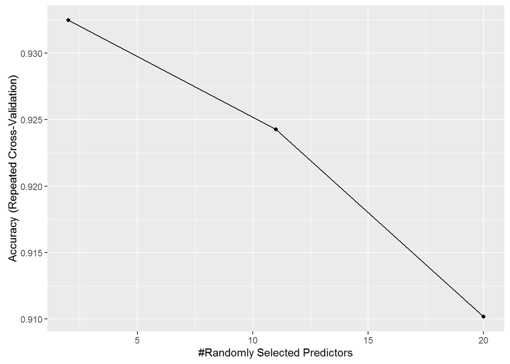

```r
ggplot(rfModel)
```

We then use this model for prediction of testing sets provided. As we used PCA to preprocess the model, we also need to pass testing set through the same PCA transformation.

```r
testing.pc <- predict(preProc, testing.sel)
testing.pred.pc <- predict(rfModel, testing.pc)
levels(testing.pred.pc) <- c("A", "B", "C", "D", "E")
testing.pred.pc
```

```
##  [1] B A B A A E D B A A B C B A E E A B B B
## Levels: A B C D E
```